# **NLP Project: Semantic Search System with Context-Aware Query Expansion**

# **Introduction**

The exponential growth of digital content has posed significant challenges for organizing, retrieving, and analyzing textual information effectively. This project focuses on solving the problem of query expansion and document retrieval within a collection of text data. Specifically, it utilizes the 20 Newsgroups Dataset, a well-known corpus of newsgroup documents categorized into 20 distinct topics, to build and evaluate an information retrieval system. Using **Latent Semantic Analysis (LSA)** and query expansion, the system enhances search accuracy by uncovering latent relationships between words and enriching queries with semantically similar terms. This approach bridges the gap between user queries and relevant documents, addressing challenges like vocabulary mismatch and topic-specific jargon.

# **Data Exploration**

**Dataset:**

We use a curated subset of the 20 Newsgroups Dataset, which consists of approximately 20,000 newsgroup documents, categorized into 20 categories such as science, technology, and sports.

Source: https://www.kaggle.com/datasets/crawford/20-newsgroups

**Dataset Dimensions:**

- Documents: ~20,000
- Features: Text body, category labels

**Key Variables:**

- Text body: The primary content of the document.
- Category labels: Serve as a ground truth to evaluate the semantic relevance of retrieved documents.

**Relationships:**

- Documents within the same category should share semantic similarity.
- Expanded query terms should closely relate to both the original query and the categories in the dataset.

**Preprocessing Techniques:**

- Remove punctuation, special characters, and stopwords.
- Tokenize text and convert to lowercase.
- Apply stemming/lemmatization.
- Vectorize text using TF-IDF.

**Dowloading the Dataset**

```python
import warnings
warnings.filterwarnings('ignore')
```

```python
import kagglehub

# Download latest version
path = kagglehub.dataset_download("crawford/20-newsgroups")

print("Path to dataset files:", path)
```

```
Path to dataset files: /root/.cache/kagglehub/datasets/crawford/20-newsgroups/versions/1
```

```python
import os
import pandas as pd

# Define dataset paths
data_dir = path  # Replace with the path to your dataset
list_csv = os.path.join(data_dir, "list.csv")

# Load list.csv
document_mapping = pd.read_csv(list_csv)

# Initialize a dataframe to store the combined data
#data = pd.DataFrame(columns=["document_id", "newsgroup", "text"])

documents=[]

for newsgroup_file in os.listdir(data_dir):
    if newsgroup_file.endswith(".txt"):  # Check for newsgroup files
        newsgroup_path = os.path.join(data_dir, newsgroup_file)
        with open(newsgroup_path, "r", encoding="utf-8", errors="ignore") as file:
            current_newsgroup = None
            current_doc_id = None
            document_text = []

            for line in file:
                line = line.strip()
                if line.startswith("Newsgroup:"):
                    # Save the previous document before starting a new one
                    if current_doc_id:
                        documents.append({
                            "document_id": current_doc_id,
                            "newsgroup": current_newsgroup,
                            "text": " ".join(document_text)
                        })
                        document_text = []

                    current_newsgroup = line.split(": ")[1]
                elif line.startswith("Document_id:"):
                    current_doc_id = line.split(": ")[1]
                elif line:  # If the line is part of the document
                    document_text.append(line)

            # Save the last document
            if current_doc_id:
                documents.append({
                    "document_id": current_doc_id,
                    "newsgroup": current_newsgroup,
                    "text": " ".join(document_text)
                })

newsgroup_data = pd.DataFrame(documents)

# Verify dataset
#print(data.head())
print(newsgroup_data.tail(3))
print(newsgroup_data.columns)
```

```
      document_id                 newsgroup  \
18827       61176  comp.sys.ibm.pc.hardware
18828       61177  comp.sys.ibm.pc.hardware
18829       61178  comp.sys.ibm.pc.hardware

                                                    text
18827  From: alerman@netcom.com (Alexander Lerman) Su...
18828  From: nbb1424@dsacng1.dsac.dla.mil (Steve Hami...
18829  From: mike@defiance.vut.edu.au (Michael Paull)...
Index(['document_id', 'newsgroup', 'text'], dtype='object')
```

**Preprocessing**

Text Cleaning

- Lowercase Conversion: Convert all text to lowercase.
- Remove Special Characters and Numbers: Retain only alphabets.
- Remove Stopwords: Exclude common words like "the", "and", "is".
- Lemmatization: Reduce words to their base form.

```python
import re
from nltk.corpus import stopwords
from nltk.stem import WordNetLemmatizer
import nltk

# Download NLTK resources
nltk.download("stopwords")
nltk.download("wordnet")
```

```
True
```

```python
# Initialize preprocessor
stop_words = set(stopwords.words("english"))
lemmatizer = WordNetLemmatizer()

# Preprocessing function
def preprocess_text(text):

    # Convert to lowercase
    text = text.lower()

    # Remove special characters and numbers
    text = re.sub(r"[^a-z\s]", "", text)

    # Tokenize and remove stopwords
    words = text.split()
    words = [word for word in words if word not in stop_words]

    # Lemmatize
    words = [lemmatizer.lemmatize(word) for word in words]

    # Rejoin words
    return " ".join(words)

# Apply preprocessing to the dataset
newsgroup_data["cleaned_text"] = newsgroup_data["text"].apply(preprocess_text)

# Verify processed text
print(newsgroup_data["cleaned_text"].head(3))
```

```
0    documentid mpyevmsbiscsupomonaedu subject medi...
1    bobcoscom bob blackshaw subject damn ferigners...
2    dreitmanoregonuoregonedu daniel r reitman atto...
Name: cleaned_text, dtype: object
```

```python
print(newsgroup_data["cleaned_text"].head(1))
```

```
0    documentid mpyevmsbiscsupomonaedu subject medi...
Name: cleaned_text, dtype: object
```

# **Algorithms and Techniques Analysis**

**Latent Semantic Analysis (LSA)**

We use LSA to uncover latent relationships between words and topics within the corpus. By representing text data in a reduced-dimensional space, LSA captures semantic similarity more effectively than raw term frequencies.

**Why LSA?**

- Dimensionality Reduction: By representing the data in a lower-dimensional semantic space, LSA mitigates issues of sparsity and synonymy, which are common in text data.
- Semantic Understanding: LSA captures underlying patterns in word usage, making it possible to identify relationships between terms and documents beyond surface-level co-occurrences.
- Query Expansion: By mapping the query to the same semantic space as the documents, it enables the identification of terms and documents that are contextually relevant to the query.

**Parameters and Models**

```python
import pandas as pd
from sklearn.feature_extraction.text import TfidfVectorizer
from sklearn.decomposition import TruncatedSVD
from sklearn.metrics.pairwise import cosine_similarity
```

**LSA and Query Expansion**

```python
# TF-IDF and LSA
vectorizer = TfidfVectorizer(max_features=5000)
tfidf_matrix = vectorizer.fit_transform(newsgroup_data["cleaned_text"])

lsa = TruncatedSVD(n_components=100, random_state=42)
lsa_matrix = lsa.fit_transform(tfidf_matrix)

# Query Expansion
def expand_query(query, vectorizer, lsa, top_n=5):
    query_vec = vectorizer.transform([query])
    query_topic_vec = lsa.transform(query_vec)
    term_scores = lsa.components_.T @ query_topic_vec.T
    top_terms = term_scores.flatten().argsort()[-top_n:][::-1]
    expanded_terms = [vectorizer.get_feature_names_out()[i] for i in top_terms]
    return expanded_terms

query = "quantum physics"
expanded_query = expand_query(query, vectorizer, lsa)
print("Expanded Query Terms:", expanded_query)
```

```
Expanded Query Terms: ['drive', 'disk', 'scsi', 'problem', 'ide']
```

**Search Implementation**

```python
from sklearn.metrics.pairwise import cosine_similarity
import numpy as np

# Function to search and rank documents
def search_documents(query, vectorizer, lsa, lsa_matrix, data, top_n=5):
    # Step 1: Expand the query
    expanded_terms = expand_query(query, vectorizer, lsa, top_n=5)
    print("Expanded Query Terms:", expanded_terms)

    # Step 2: Transform the expanded query into the LSA space
    expanded_query = " ".join(expanded_terms)  # Combine expanded terms into a single query string
    query_vec = vectorizer.transform([expanded_query])  # Vectorize expanded query
    query_lsa_vec = lsa.transform(query_vec)  # Transform to LSA space

    # Step 3: Calculate similarity scores
    similarity_scores = cosine_similarity(query_lsa_vec, lsa_matrix)  # Compute cosine similarity

    # Step 4: Rank documents by similarity
    ranked_indices = np.argsort(similarity_scores[0])[::-1]  # Sort scores in descending order
    top_indices = ranked_indices[:top_n]  # Get top N results

    # Step 5: Retrieve and return the top documents
    top_documents = data.iloc[top_indices][["document_id", "newsgroup", "cleaned_text"]]
    top_documents["similarity_score"] = similarity_scores[0][top_indices]
    return top_documents

# Example usage
query = "quantum physics"
top_results = search_documents(query, vectorizer, lsa, lsa_matrix, newsgroup_data, top_n=5)
print("\nTop Results:")
print(top_results)
```

```
Expanded Query Terms: ['drive', 'disk', 'scsi', 'problem', 'ide']

Top Results:
      document_id                 newsgroup  \
18462       60807  comp.sys.ibm.pc.hardware
18108       60357  comp.sys.ibm.pc.hardware
18118       60367  comp.sys.ibm.pc.hardware
18260       60512  comp.sys.ibm.pc.hardware
18158       60407  comp.sys.ibm.pc.hardware

                                            cleaned_text  similarity_score
18462  wnggeopubcca william ng subject q scsiide ie h...          0.882040
18108  shawfeanorxelcom greg shaw subject ide v scsi ...          0.858426
18118  wlsmithvalveheartrriuwoca wayne smith subject ...          0.856241
18260  wlsmithvalveheartrriuwoca wayne smith subject ...          0.854555
18158  glangsleesrlfordcom gordon lang subject adapte...          0.851122
```

# **Visualization**

```python
import matplotlib.pyplot as plt
```

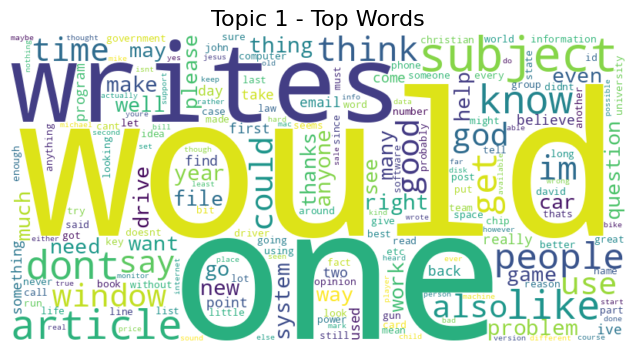

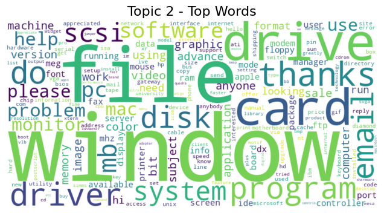

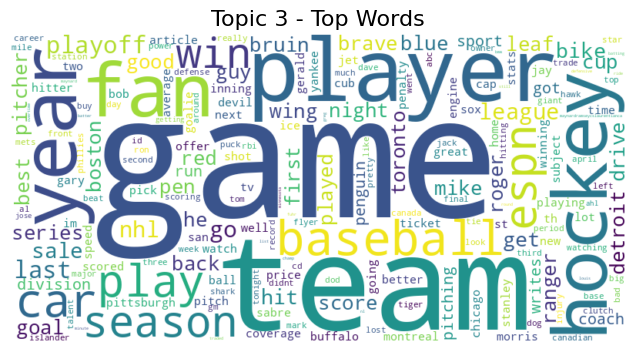

```python
from wordcloud import WordCloud

# Generate word clouds for the top topics
for i, topic in enumerate(lsa.components_[:3]):  # Top 3 topics
    word_weights = {vectorizer.get_feature_names_out()[j]: topic[j] for j in range(len(topic))}
    wordcloud = WordCloud(width=800, height=400, background_color='white').generate_from_frequencies(word_weights)

    plt.figure(figsize=(8, 4))
    plt.imshow(wordcloud, interpolation="bilinear")
    plt.title(f"Topic {i+1} - Top Words", fontsize=16)
    plt.axis("off")
    plt.show()
```

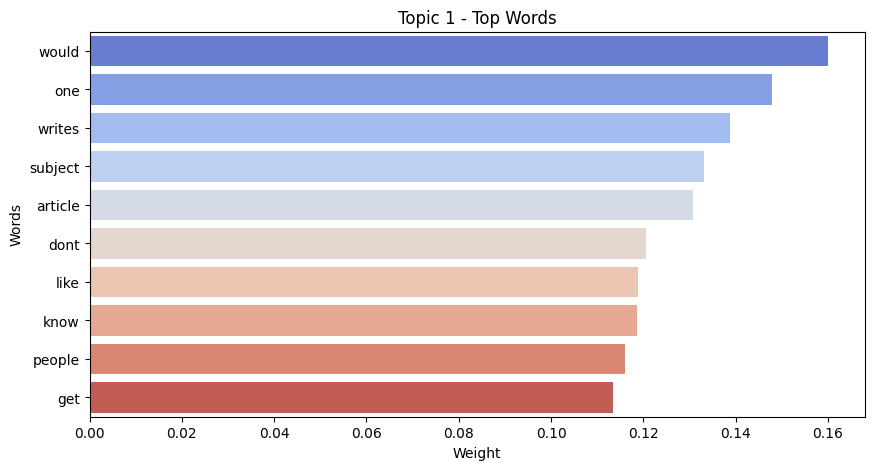

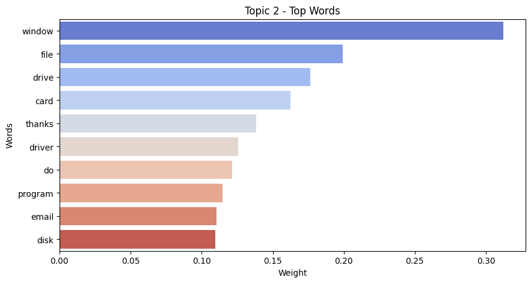

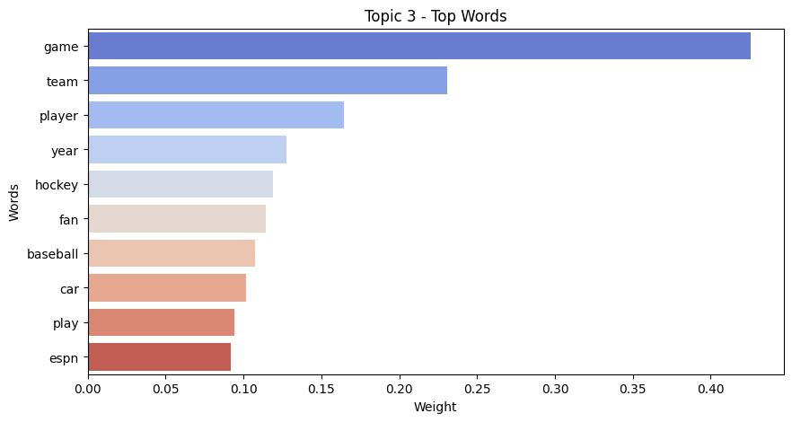

```python
import seaborn as sns
# Compare top 3 and bottom 3 topics
topics_to_compare = list(range(3)) # First 3 topics

for i in topics_to_compare:
    top_words_indices = lsa.components_[i].argsort()[-10:][::-1]  # Top 10 words
    top_words = [vectorizer.get_feature_names_out()[j] for j in top_words_indices]
    top_weights = lsa.components_[i][top_words_indices]

    plt.figure(figsize=(10, 5))
    sns.barplot(x=top_weights, y=top_words, palette="coolwarm")
    plt.title(f"Topic {i+1} - Top Words")
    plt.xlabel("Weight")
    plt.ylabel("Words")
    plt.show()
```

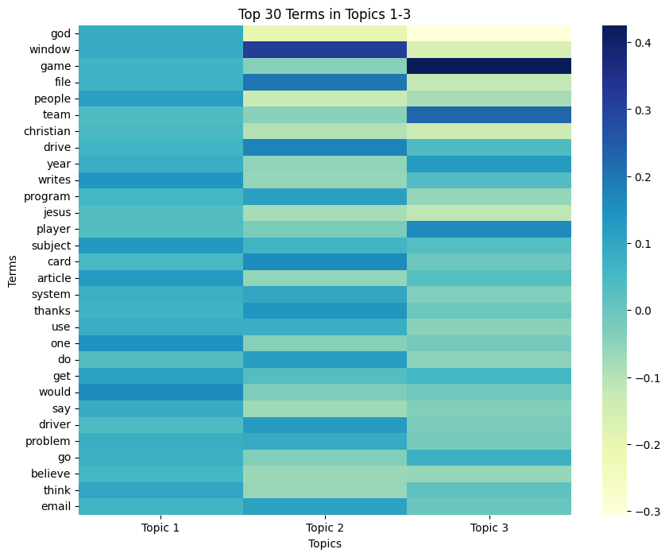

```python
# Create a DataFrame for the top 3 topics
topics_df = pd.DataFrame(
    lsa.components_[:3].T,
    columns=["Topic 1", "Topic 2", "Topic 3"],
    index=vectorizer.get_feature_names_out()
)

# Get the top terms for these topics
top_terms = (
    topics_df.abs().sum(axis=1).nlargest(30).index  # Terms with high cumulative weights
)

# Plot heatmap for the top terms
plt.figure(figsize=(10, 8))
sns.heatmap(
    topics_df.loc[top_terms],
    annot=False, cmap="YlGnBu", cbar=True
)
plt.title("Top 30 Terms in Topics 1-3")
plt.xlabel("Topics")
plt.ylabel("Terms")
plt.show()
```

**Testing Metrics:**

- **Precision:** Measures the relevance of top-k results.
- **Recall:** Measures how well relevant documents are retrieved.
- **Mean Reciprocal Rank (MRR):** Evaluates the ranking quality.

```python
# Example ground truth (adjust based on your dataset)
query = "quantum physics"
relevant_docs = ['60512', '60357']  # Document IDs for relevant results
```

```python
from sklearn.metrics import precision_score, recall_score

def evaluate_relevance(query, expanded_query, vectorizer, lsa, data, relevant_docs, top_k=5):
    # Transform expanded query to LSA space
    query_vec = vectorizer.transform([" ".join(expanded_query)])
    query_topic_vec = lsa.transform(query_vec)

    # Compute cosine similarity of query with all documents
    from sklearn.metrics.pairwise import cosine_similarity
    similarities = cosine_similarity(query_topic_vec, lsa_matrix)[0]

    # Rank documents by similarity
    ranked_docs = data.iloc[similarities.argsort()[::-1]]["document_id"].values[:top_k]

    # Calculate Precision and Recall
    y_true = [1 if doc in relevant_docs else 0 for doc in ranked_docs]
    y_pred = [1] * len(y_true)  # Top-k are treated as retrieved
    precision = sum(y_true) / len(y_true)
    recall = sum(y_true) / len(relevant_docs)

    # Calculate Mean Reciprocal Rank (MRR)
    mrr = 0
    for rank, doc in enumerate(ranked_docs, start=1):
        if doc in relevant_docs:
            mrr = 1 / rank
            break

    # Display Metrics
    print(f"Precision: {precision:.4f}")
    print(f"Recall: {recall:.4f}")
    print(f"MRR: {mrr:.4f}")

    return ranked_docs, precision, recall, mrr
```

```python
ranked_docs, precision, recall, mrr = evaluate_relevance(query, expanded_query, vectorizer, lsa, newsgroup_data, relevant_docs)
print("Ranked Documents:", ranked_docs)
```

```
Precision: 0.4000
Recall: 1.0000
MRR: 0.5000
Ranked Documents: ['60807' '60357' '60367' '60512' '60407']
```

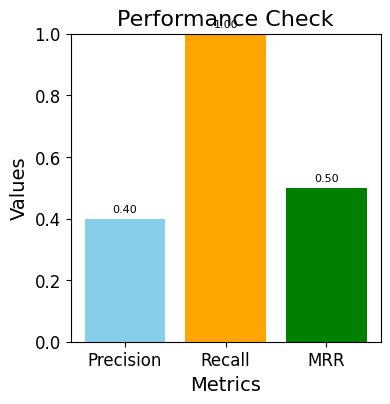

```python
# Performance Metrics
metrics = ["Precision", "Recall", "MRR"]
values = [precision, recall, mrr]  # Replace with your computed metrics

# Bar Chart for Metrics
plt.figure(figsize=(4, 4))
plt.bar(metrics, values, color=['skyblue', 'orange', 'green'])
plt.ylim(0, 1)
plt.title("Performance Check", fontsize=16)
plt.xlabel("Metrics", fontsize=14)
plt.ylabel("Values", fontsize=14)
plt.xticks(fontsize=12)
plt.yticks(fontsize=12)

# Annotate the bars with exact values
for i, v in enumerate(values):
    plt.text(i, v + 0.02, f"{v:.2f}", ha='center', fontsize=8)

plt.show()
```

**Outcome**

- **Precision**: Higher precision indicates more retrieved documents are relevant.
- **Recall**: Higher recall indicates more relevant documents are retrieved.
- **MRR**: Higher MRR indicates that a relevant document appears earlier in the ranked results.

# **Conclusion**

**Open Questions:**

1. How can this approach generalize across languages with minimal resources?
2. What strategies can better balance precision and recall in domain-specific corpora?
3. What additional techniques, such as integrating more advanced NLP models or incorporating context-aware approaches, could enhance the accuracy of document retrieval?

```python
!pwd
```

```
/content
```

```python
!jupyter nbconvert --to html NLP_final_project.ipynb
```

```
[NbConvertApp] Converting notebook NLP_final_project.ipynb to html
[NbConvertApp] WARNING | Alternative text is missing on 8 image(s).
[NbConvertApp] Writing 1388486 bytes to NLP_final_project.html
```